# Cálculo numérico y aplicaciones de las integrales

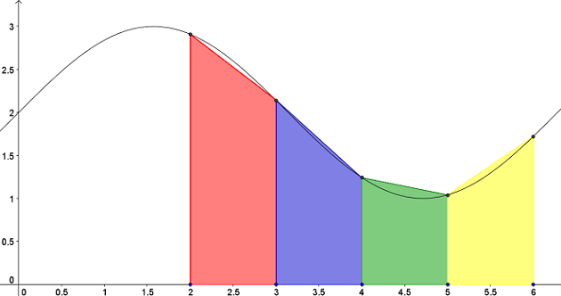

## 1. Introducción

En ingeniería y electrónica, muchas veces necesitamos calcular **áreas, energías, cargas o volúmenes** que no se pueden obtener con fórmulas exactas. En esos casos usamos la **integración numérica**, que aproxima la integral sumando áreas pequeñas.

Cuando una magnitud depende de **dos o tres variables** (por ejemplo, densidad en una superficie o volumen), usamos **integrales dobles o triples**.

## 2. Integración numérica

### A) Concepto

El valor de una integral definida $\int_a^b f(x),dx$ representa el **área bajo la curva** de (f(x)) entre (a) y (b).

Cuando no podemos obtenerla analíticamente, la aproximamos mediante **métodos numéricos**.

### B) Regla de los trapecios

La explicación de clase está basada en esta [fuente](https://es.khanacademy.org/math/ap-calculus-ab/ab-integration-new/ab-6-2/a/understanding-the-trapezoid-rule) que consultar como repaso. También puedes repasar estos conceptos en este [video](https://www.youtubetrimmer.com/view/?v=S8Htl7olCjA&start=387&end=526&loop=0)

La idea es aproximar la curva por tramos rectos formando pequeños trapecios y así podemos obtener aproximaciones más precisas que al utilizar rectángulos (es decir, “sumas de Riemann”)

En resumen:

$\int_a^b f(x),dx \approx \frac{h}{2},[f(x_0) + 2f(x_1) + 2f(x_2) + \dots + 2f(x_{n-1}) + f(x_n)]$

donde $(h = \dfrac{b - a}{n})$ es el ancho de cada subintervalo.

### C) Ejercicios aplicando regla de los trapecios

**1.** Resolver el problema de práctica y el problema desafío que aparecen en nuestra [fuente principal](https://es.khanacademy.org/math/ap-calculus-ab/ab-integration-new/ab-6-2/a/understanding-the-trapezoid-rule)

**2.** Resuelve [estos ejercicios](https://es.khanacademy.org/math/ap-calculus-ab/ab-integration-new/ab-6-2/e/trapezoid-rule) aplicando regla de los trapecios